# Inquiries and Answer strategies | Requêtes et stratégies de réponse

2026-06-05

## How we define and answer questions

How we define and answer questions

Comment nous définissons les questions et y répondons

**Inquiry**: research question

$\rightarrow$ **Estimand**: the true answer to the inquiry

**Requête**: question de recherche

$\rightarrow$ **Estimande**: la vraie réponse à la question

**Answer strategy**: how you will generate answers from the data

$\rightarrow$ **Estimate**: empirical answer to your inquiry | réponse empirique à votre demande

**Stratégie de réponse**: comment allez-vous générer des réponses à partir des données

$\rightarrow$ **Estimation**: réponse empirique à votre demande

## Inquiries

Inquiries

Requêtes $\rightarrow$ estimands | paramètres

- Your inquiry is your *question*
- Your estimand is the *true answer* to the question
- Votre demande est votre *question*
- Votre estimation est la *vraie réponse*

## Inquiries

Inquiries

Requêtes

**What is your question?**

Is the average effect positive in the sample?

What is the average effect in the sample?

What is the effect among people who comply with treatment?

What is the effect among women in the sample?

**Quelle est votre question?**

L’effet moyen est-il positif dans l’échantillon ?

Quel est l’effet moyen dans l’échantillon?

Quel est l’effet sur les personnes qui se conforment au traitement?

Quel est l’effet sur les femmes de l’échantillon?

## Inquiries

Inquiries

Requêtes $\rightarrow$ estimands | paramètres

| Inquiry | Estimand |
| --- | --- |
| What is the causal effect of CCTs on gender inequality? | ? |
| What is the causal effect of coffee on whether I got the quiz right? | ? |
| Is the average effect positive? | ? |

| Requêtes | Paramètres |
| --- | --- |
| Quel est l’effet causal des CCTs sur l’inégalité entre les sexes ? | ? |
| Quel est l’effet causal du café sur le fait que j’ai bien répondu au questionnaire ? | ? |
| L’effet moyen est-il positif ? | ? |

## Inquiries

Inquiries

Requêtes $\rightarrow$ estimands | paramètres

| Inquiry | Estimand |
| --- | --- |
| What is the causal effect of CCTs on gender inequality? | -0.2 |
| What is the causal effect of coffee on whether I got the quiz right? | 0.05 |
| Is the average effect positive? | Yes |

| Requêtes | Paramètre |
| --- | --- |
| Quel est l’effet causal des CCTs sur l’inégalité entre les sexes ? | -0.2 |
| Quel est l’effet causal du café sur le fait que j’ai bien répondu au questionnaire ? | 0.05 |
| L’effet moyen est-il positif ? | Oui |

## Inquiries

Inquiries

Requêtes

**Sample average treatment effect** Average difference between treated and control potential outcomes *among sampled units*

**Effet moyen du traitement sur l’échantillon** Différence moyenne entre les résultats potentiels des unités traitées et des unités de contrôle *parmi les unités échantillonnées*

## Inquiries

Inquiries

Requêtes

**Sample average treatment effect:**

$$\frac{1}{n} \left\{\sum_{i \leq n} Y_i(1) - \sum_{i \leq n} Y_i(0) \right\}$$

**Effet moyen du traitement sur l’échantillon :**

$$\frac{1}{n} \left\{\sum_{i \leq n} Y_i(1) - \sum_{i \leq n} Y_i(0) \right\}$$

## Answer strategies

Answer strategies

Stratégies de réponse

Answer strategy takes *data* and returns an *estimate* (answer)  
Many answer strategies could target same inquiry!

La stratégie de réponse prend des *données* et renvoie une *estimation* (réponse)  
. Plusieurs stratégies de réponse peuvent cibler la même question!

Examples:

- Linear regression with $Y \sim Z + X$ (take coefficient on $Z$)
- Probit regression $\rightarrow$ difference in predicted probability

Exemples: - Régression linéaire avec $Y \sim Z + X$ (prendre le coefficient sur $Z$) - Régression probit $\rightarrow$ différence dans la probabilité prédite

## How to select an answer strategy

How to select an answer strategy

Comment choisir une stratégie de réponse ?

**Analyze as you randomize**:

1. Plug-in principle
2. Reverse distortions created by your design

**Analysez selon le niveau de randomisation** :

1. Principe de l’enfichage
2. Inverser les distorsions créées par votre conception

## Plug-in principle

Plug-in principle

Principe de l’enfichage

To estimate unknown quantities, “plug in” observed data and apply the same function (e.g., average)

Pour estimer des quantités inconnues, il faut “brancher” les données observées et appliquer la même fonction (par exemple, la moyenne).

## Plug-in principle

Plug-in principle

Principe de l’enfichage

**Example**: sample average treatment effect after complete random assignment

- Inquiry: Average treated potential outcome - Average control potential outcome
- Answer strategy: Average outcome in treatment group - Average outcome in control group

**Exemple** : effet moyen du traitement de l’échantillon après une randomisaion complète

- Enquête : Résultat potentiel moyen du traitement - Résultat potentiel moyen du contrôle
- Stratégie de réponse : Résultat moyen dans le groupe de traitement - Résultat moyen dans le groupe de contrôle

## Plug-in principle

Plug-in principle

Principe de l’enfichage

Inquiry:

$$\frac{1}{n} \sum_{i \leq n} Y_i(1) - \frac{1}{n} \sum_{i \leq n} Y_i(0)$$
**Example**: sample average treatment effect after complete random assignment

Answer strategy:

$$\frac{1}{n_1} \sum_{i : Z_i = 1} Y_i - \frac{1}{n_0} \sum_{i : Z_i = 0} Y_i$$

Requête:

$$\frac{1}{n} \sum_{i \leq n} Y_i(1) - \frac{1}{n} \sum_{i \leq n} Y_i(0)$$
**Exemple**: effet moyen du traitement de l’échantillon après une randomisation complète

Stratégie de réponse:

$$\frac{1}{n_1} \sum_{i : Z_i = 1} Y_i - \frac{1}{n_0} \sum_{i : Z_i = 0} Y_i$$

## Plug-in principle

Plug-in principle

Principe de l’enfichage

**Example**: sample average treatment effect after complete random assignment

Inquiry:

$$\frac{1}{n} \sum_{i \leq n} Y_i(1) - \frac{1}{n} \sum_{i \leq n} Y_i(0)$$

Answer strategy:

summarize(data, estimate = mean(Y[Z == 1]) - mean(Y[Z == 0]))

**Example**: effet moyen du traitement de l’échantillon après une randomisation complète

Requête:

$$\frac{1}{n} \sum_{i \leq n} Y_i(1) - \frac{1}{n} \sum_{i \leq n} Y_i(0)$$

Stratégie de réponse:

summarize(data, estimate = mean(Y[Z == 1]) - mean(Y[Z == 0]))

## Applying the answer strategy

Applying the answer strategy

Application de la stratégie de réponse

Let’s look at just the top six rows in our observed data:

| ID | X | Z | Y |
| --- | --- | --- | --- |
| 001 | 0 | 1 | 0.09 |
| 002 | 1 | 1 | 1.05 |
| 003 | 1 | 0 | 0.97 |
| 004 | 1 | 1 | 0.68 |
| 005 | 0 | 0 | 0.08 |
| 006 | 1 | 0 | 0.81 |

Examinons uniquement les six premières lignes de nos données observées :

| ID | X | Z | Y |
| --- | --- | --- | --- |
| 001 | 0 | 1 | 0.09 |
| 002 | 1 | 1 | 1.05 |
| 003 | 1 | 0 | 0.97 |
| 004 | 1 | 1 | 0.68 |
| 005 | 0 | 0 | 0.08 |
| 006 | 1 | 0 | 0.81 |

## Applying the answer strategy

Applying the answer strategy

Application de la stratégie de réponse

Our answer strategy:

`summarize(data, mean(Y[Z == 1]) - mean(Y[Z == 0]))` (difference-in-means)

Our estimate:

```
   estimate
1 0.1370886
```

Notre stratégie de réponse :

`summarize(data, mean(Y[Z == 1]) - mean(Y[Z == 0]))` (difference-in-means)

Notre estimation :

```
   estimate
1 0.1370886
```

## How to assess your answers

How to assess your answers

Comment évaluer vos réponses

- Assess your *answer strategy* through simulation (diagnosis)
- Assess your *answer* using uncertainty estimate (standard errors, confidence intervals)
- Évaluer votre *stratégie de réponse* par la simulation (diagnostic)
- Évaluez votre *réponse* en utilisant une estimation d’incertitude (erreurs type, intervalles de confiance).

## Answer strategies

Answer strategies

Stratégies de réponse

We want an answer strategy that is:

1. *unbiased* (valid),
2. *low variance* (reliable), and
3. for which we can characterize our uncertainty

Nous voulons une stratégie de réponse qui soit :

1. *non biaisée* (valide),
2. *faible variance* (fiable), et
3. pour lesquels nous pouvons caractériser notre incertitude

## Answer strategies

Answer strategies

Stratégies de réponse

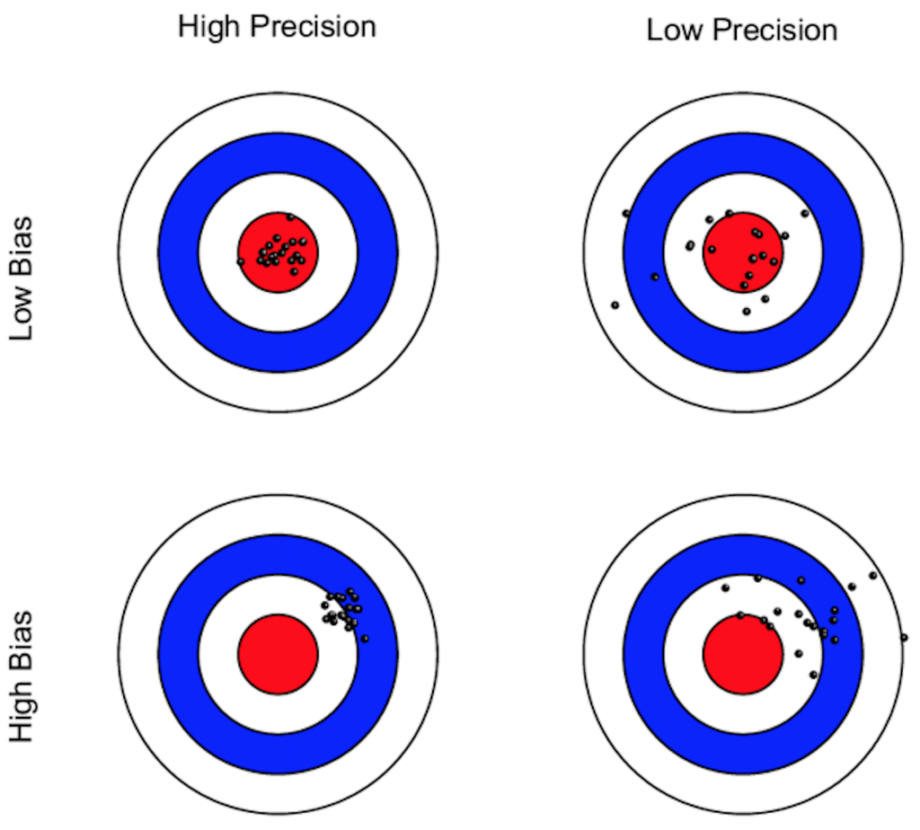

## How do we assess answer strategies

How do we assess answer strategies

Comment évaluer les stratégies de réponse

**Sampling distribution:** What happens when we run the experiment many times?

**Distribution d’échantillonnage:** Que se passe-t-il si nous répétons l’expérience plusieurs fois ?

## What is a sampling distribution?

What is a sampling distribution?

Qu’est-ce qu’une distribution d’échantillonnage ?

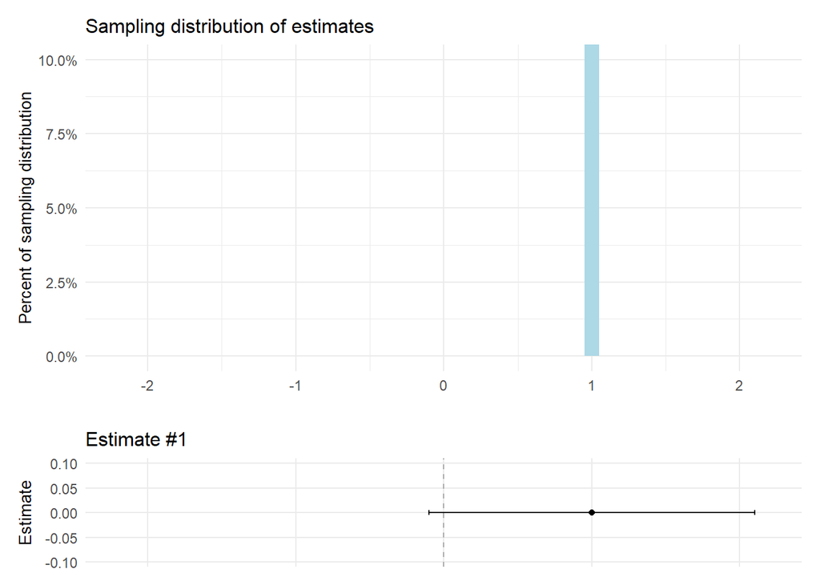

## What is a sampling distribution?

What is a sampling distribution?

Qu’est-ce qu’une distribution d’échantillonnage ?

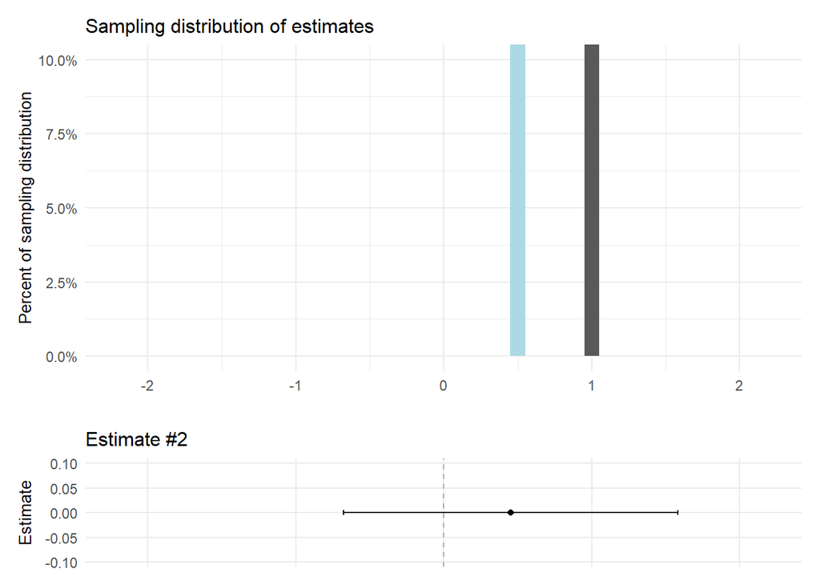

## What is a sampling distribution?

What is a sampling distribution?

Qu’est-ce qu’une distribution d’échantillonnage ?

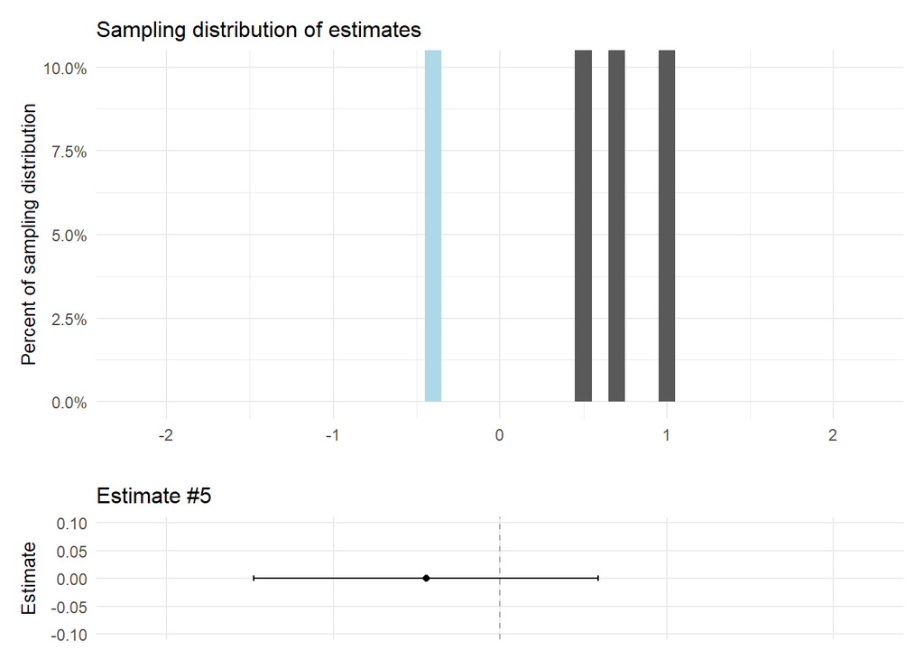

## What is a sampling distribution?

What is a sampling distribution?

Qu’est-ce qu’une distribution d’échantillonnage ?

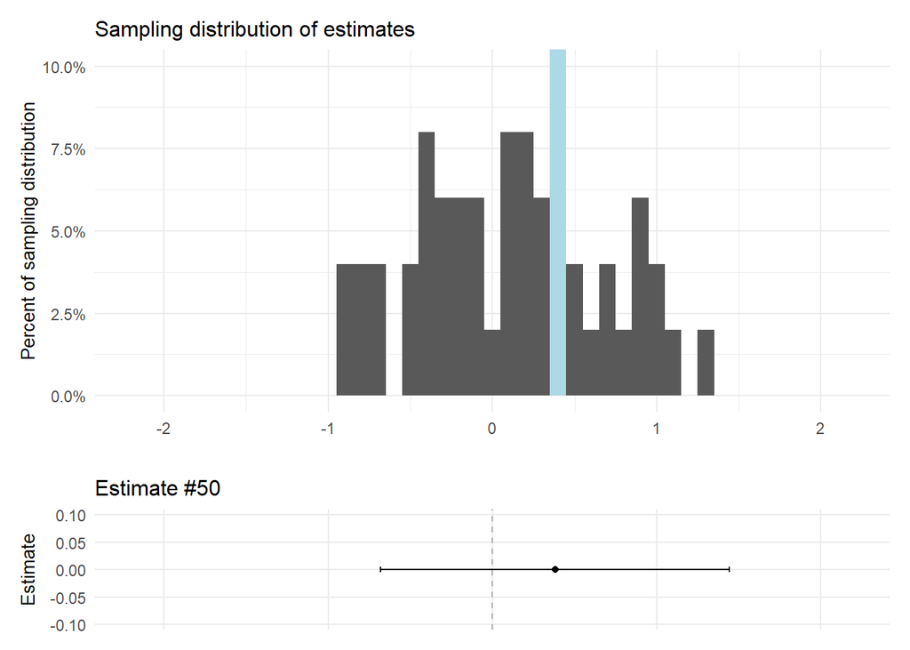

## What is a sampling distribution?

What is a sampling distribution?

Qu’est-ce qu’une distribution d’échantillonnage ?

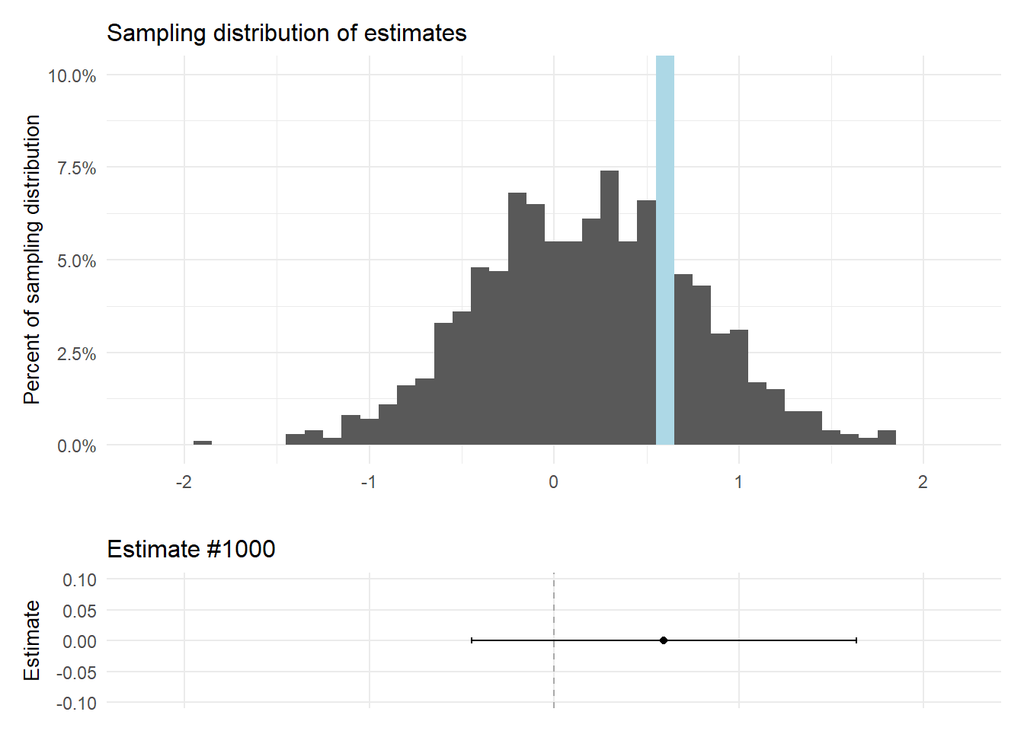

## What is a sampling distribution?

What is a sampling distribution?

Qu’est-ce qu’une distribution d’échantillonnage ?

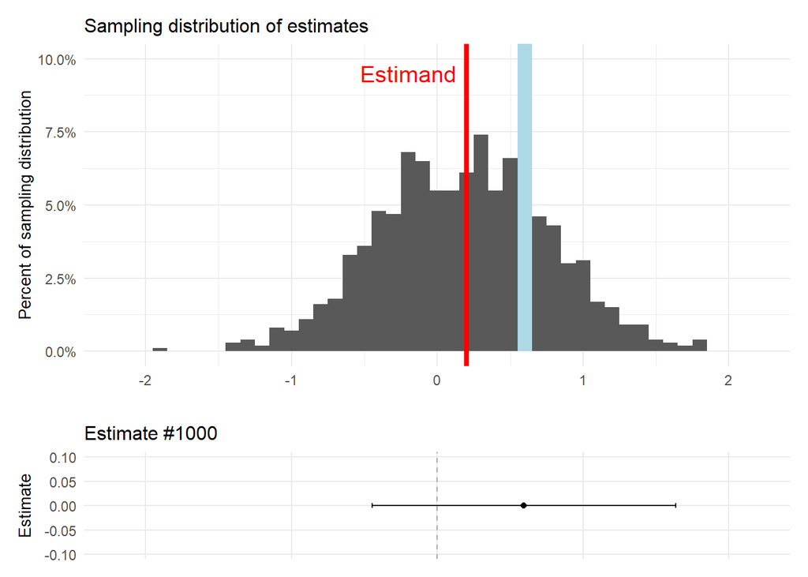

## How do we assess answer strategies

How do we assess answer strategies

Comment évaluer les stratégies de réponse

**Bias:**

What’s the average difference between our estimates and the estimand?

**Standard deviation of estimates:**

How much do our estimates vary?

**Root mean squared error:**

How far off are we on average? (Combines bias and s.d.!)

**Bias:**

Quelle est la différence moyenne entre nos estimations et le paramètre ?

**Écart-type des estimations:**

De combien varient nos estimations ?

**Erreur quadratique moyenne:**

Quelle est la différence moyenne entre nos estimations et le paramètre ? (Combine le biais et l’écart-type !)

## How do we assess answer strategies

How do we assess answer strategies

Comment évaluer les stratégies de réponse

**Bias:**

`mean(estimate - estimand)`

**Standard deviation of estimates:**

`sd(estimate))`

`sqrt(mean((estimate - estimand)^2))`

**Bias:**

`moyenne(estimation - paramètre)`

**Écart-type des estimations:**

`sd(estimation))`

**Erreur quadratique moyenne:**

`sqrt(mean((estimate - estimand)^2))`

## Unbiased, precise

Unbiased, precise

Sans biais, précis

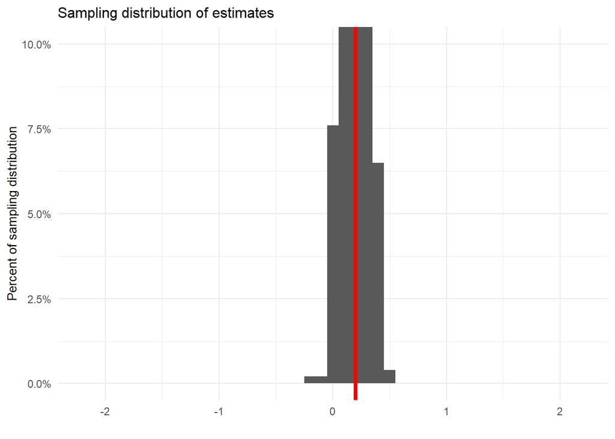

## Unbiased, imprecise

Unbiased, imprecise

Sans biais, imprécis

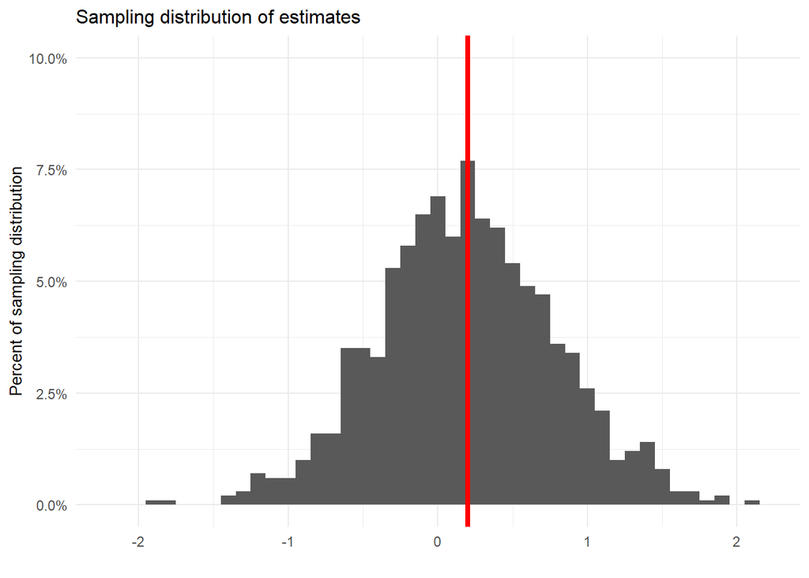

## Biased, precise

Biased, precise

Biaisé, précis

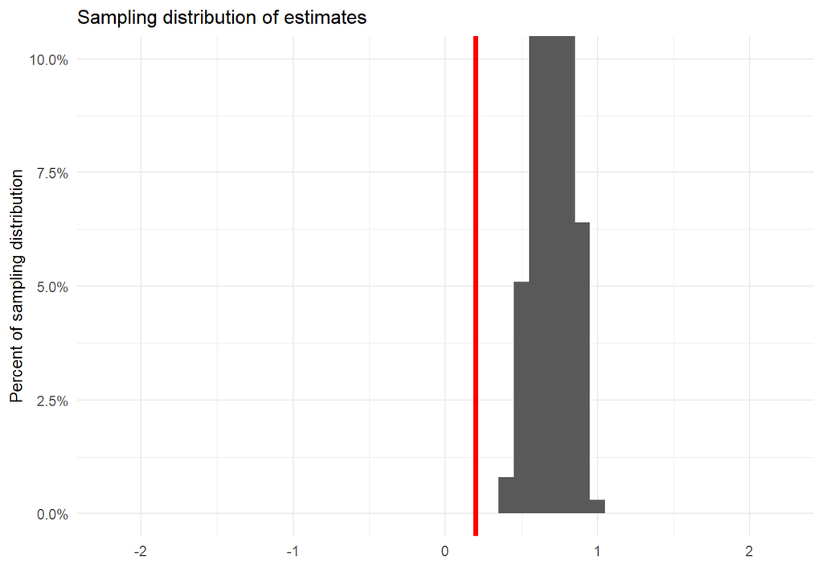

## Biased, imprecise

Biased, imprecise

Biaisé, imprécis

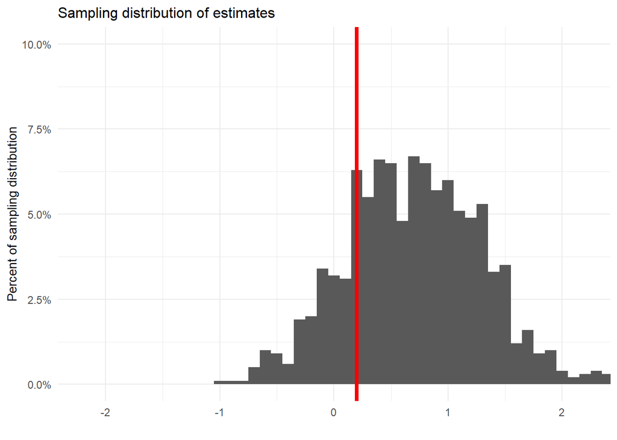

## Assessing the answer strategy

Assessing the answer strategy

Évaluation de la stratégie de réponse

Back to example:

- **Experiment:** complete random assignment
- **Inquiry:** sample average treatment effect
- **Answer strategy:** difference-in-means

Retour à l’exemple :

- **Expérience:** Randomisation complète
- **Interrogation:** effet moyen du traitement sur l’échantillon
- **Stratégie de réponse:** différence de moyenne

| assignment | answer strategy | diagnosand | estimate |
| --- | --- | --- | --- |
| complete | difference-in-means | bias | 0.00 |
| complete | difference-in-means | sd_estimate | 0.07 |
| complete | difference-in-means | rmse | 0.07 |

## Assessing answers

Assessing answers

Évaluer les réponses

*Standard error* - estimate of the true standard deviation of the sampling distribution

*Confidence interval* - interval designed to cover the true estimand 95% of the time

*Erreur type* - estimation de l’écart type réel de la distribution d’échantillonnage.

*Intervalle de confiance* - intervalle conçu pour couvrir la vraie valeur du paramètre dans 95 % des cas.

`difference_in_means(Y ~ Z, data = experiment_df)`

| Estimate | Standard error | Confidence interval |
| --- | --- | --- |
| 0.08 | 0.07 | (-0.06, 0.22) |

## Review

Review

Révision

**Analyze as you randomize**:

1. Plug-in principle
2. Correct for distortions

Select an answer strategy that is unbiased, low variance, and quantify level of uncertainty

**Analysez selon le niveau de randomisation** :

1. Principe de l’enfichage
2. Corriger les distorsions

Sélectionner une stratégie de réponse sans biais, à faible variance, et quantifier le niveau d’incertitude.

## New example: block randomization

Inquiry: sample average treatment effect

Random assignment procedure: block randomization

Requête : effet moyen du traitement sur l’échantillon

Procédure d’assignation aléatoire: randomisation par blocs

`mutate(data, Z = block_ra(blocks = X, block_prob = c(0.2, 0.5)))`

First six rows of data:

| ID | X | Z | Y |
| --- | --- | --- | --- |
| 001 | 1 | 0 | 0.88 |
| 002 | 1 | 0 | 0.84 |
| 003 | 1 | 1 | 0.90 |
| 004 | 1 | 0 | 0.91 |
| 005 | 0 | 1 | -0.09 |
| 006 | 0 | 0 | -0.23 |

Six premières lignes de données :

| ID | X | Z | Y |
| --- | --- | --- | --- |
| 001 | 0 | 0 | 0.23 |
| 002 | 0 | 0 | -0.31 |
| 003 | 1 | 0 | 1.18 |
| 004 | 0 | 0 | -0.40 |
| 005 | 1 | 0 | 0.66 |
| 006 | 1 | 1 | 1.43 |

## New example: block randomization

New example: block randomization

Nouvel exemple : la randomisation par blocs

Inquiry: sample average treatment effect

Random assignment procedure: block randomization

Requête : effet moyen du traitement sur l’échantillon

Procédure d’assignation aléatoire : randomisation par blocs

Summary of same data:

| X | Z = 0 | Z = 1 |
| --- | --- | --- |
| 0 | 100 | 25 |
| 1 | 62 | 63 |

## New example: block randomization

New example: block randomization

Nouvel exemple : la randomisation par blocs

What answer strategy should we select? | Quelle stratégie de réponse devons-nous choisir ?

## New example: block randomization

New example: block randomization

Nouvel exemple : la randomisation par blocs

1. Plug-in principle

Two mini-experiments $\rightarrow$ two difference-in-means estimates $\rightarrow$ average across blocks

1. Principe de l’enfichage

Deux mini-expériences $\rightarrow$ deux estimations de la différence des moyennes $\rightarrow$ moyenne entre les blocs

## New example: block randomization

New example: block randomization

Nouvel exemple : la randomisation par blocs

| X | block_estimate |
| --- | --- |
| 0 | 0.29 |
| 1 | 0.13 |

| estimate |
| --- |
| 0.21 |

## Assessing our answer strategy

Assessing our answer strategy

Évaluer notre stratégie de réponse

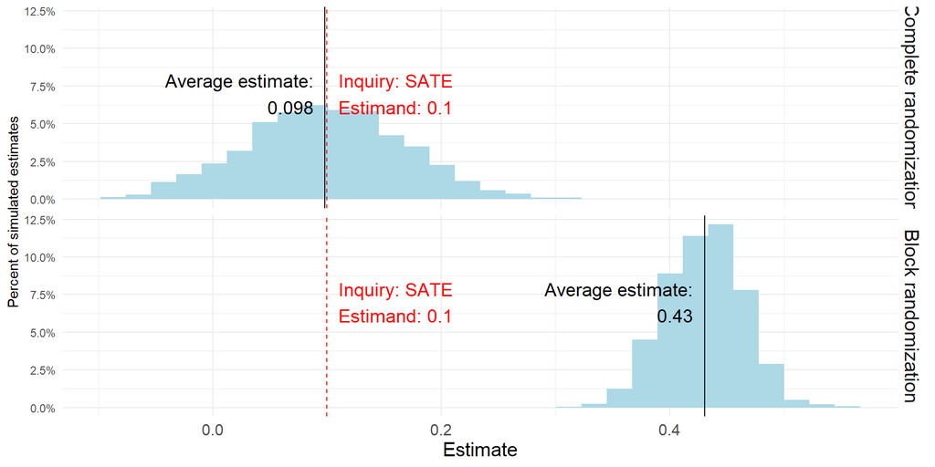

## What answer strategy should we select?

What answer strategy should we select?

Quelle stratégie de réponse devons-nous choisir ?

2. Reverse distortions

Probability of assignment differs across units!

Reverse by weights: $\frac{1}{\mathrm{Pr}(\mathrm{assignment})}$

2. Inverser les distorsions

La probabilité d’affectation diffère d’une unité à l’autre !

Inversion par les poids : $\frac{1}{\mathrm{Pr}(\mathrm{assignment})}$

## What answer strategy should we select?

What answer strategy should we select?

Quelle stratégie de réponse devons-nous choisir ?

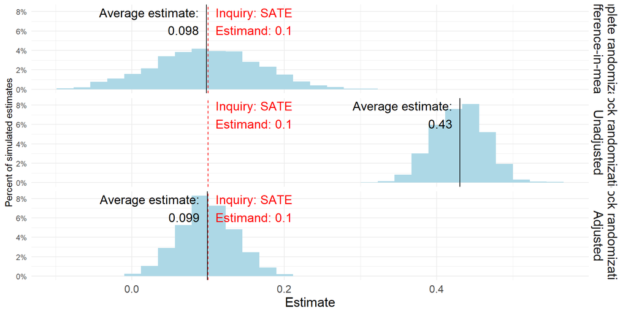

## Returning to assessing answers

Returning to assessing answers

Retour à l’évaluation des réponses

| design | estimator | estimate | std.error | conf.low | conf.high |
| --- | --- | --- | --- | --- | --- |
| complete | difference-in-means | 0.10 | 0.07 | -0.03 | 0.24 |
| blocked | difference-in-means | 0.45 | 0.07 | 0.31 | 0.59 |

## How to select a standard error estimator

How to select a standard error estimator

Comment sélectionner un estimateur de l’erreur type

Analyze as you randomize

1. Complete randomization: robust standard errors (just believe us!)
2. Clustered random assignment: cluster-robust s.e. at level where assignment took place

L’orientation est plus difficile !

1. Utiliser des erreurs type robustes
2. L’affectation est-elle en grappe (cluster) ? $\rightarrow$ Erreur type robuste en grappe au niveau où l’assignation a eu lieu.
3. L’enquête porte-t-elle sur une population dont l’échantillon a été sélectionné au hasard ? Les conseils ci-dessus peuvent ne pas s’appliquer.

## How do we assess uncertainty estimates

How do we assess uncertainty estimates

Comment évaluer les estimations de l’incertitude

1. Standard error is an estimate! Calculate bias
2. Compare rate CI contains (“covers”) the truth – “coverage” – to selected nominal rate e.g. 95%
1. L’erreur type est une estimation ! Calculer le biais
2. Comparer le taux d’IC qui contient (“couvre”) la vérité – “couverture” – au taux nominal sélectionné, par exemple 95%.

| assignment | diagnosand | estimate |
| --- | --- | --- |
| complete | se_bias | 0.00 |
| blocked | se_bias | 0.04 |
| blocked_adjusted | se_bias | 0.00 |
| complete | coverage | 0.95 |
| blocked | coverage | 0.00 |
| blocked_adjusted | coverage | 0.94 |

## Review

Review

Révision

1. **Choose an answer strategy** using the plug-in principle and then reverse distortions from the design.
2. **Assess your answer strategy** (through simulation): is it unbiased and low variance? Can you characterize uncertainty?
1. **Choisissez une stratégie de réponse** en utilisant le principe du “plug-in” et en inversant les distorsions de la conception.
2. **Évaluez votre stratégie de réponse** (par simulation) : est-elle sans biais et à faible variance ? Pouvez-vous caractériser l’incertitude ?

## Review

Review

Révision

3. **Choose an unbiased estimator of your uncertainty**. Use robust standard errors. If you use cluster assignment, cluster-robust standard errors.
4. **Assess your answers**: is the standard error small (confidence interval narrow) enough to be confident in your decision?
3. **Choisissez un estimateur sans biais de votre incertitude**. Utilisez des erreurs type robustes. Si vous utilisez une assignation par grappes, utilisez des erreurs type robustes.
4. **Évaluez vos réponses** : l’erreur type est-elle suffisamment petite (intervalle de confiance étroit) pour que vous soyez sûr de votre décision ?